# Final Project

```python
boulder[boulder.GIS_acreage >= 175]
```

| strap | city | builtYear | TotalFinishedSF | GIS_acreage | GIS_sqft | designCodeDscr | bsmtTypeDscr | bsmtType | totalAssessedVal | totalActualVal |
| --- | --- | --- | --- | --- | --- | --- | --- | --- | --- | --- |
| R0054130 | UNINCORPORATED | 1900 | 496 | 245.915 | 10712060 | 1 Story - Ranch | 0 | 0 | 20020 | 280000 |

```python
boulder[boulder.TotalFinishedSF>=15000]
```

| strap | city | builtYear | TotalFinishedSF | GIS_acreage | GIS_sqft | designCodeDscr | bsmtTypeDscr | bsmtType | totalAssessedVal | totalActualVal |
| --- | --- | --- | --- | --- | --- | --- | --- | --- | --- | --- |
| R0032349 | UNINCORPORATED | 1996 | 19044 | 14.163 | 616947 | 2-3 Story | 0 | 0 | 205885 | 2879500 |

```python
#Looking at correlations between continuous variables
boulder[['builtYear', 'TotalFinishedSF', 'totalAssessedVal', 'totalActualVal','GIS_acreage']].corr()
```

|  | builtYear | TotalFinishedSF | totalAssessedVal | totalActualVal | GIS_acreage |
| --- | --- | --- | --- | --- | --- |
| builtYear | 1.000000 | 0.398658 | 0.009698 | 0.009135 | -0.004865 |
| TotalFinishedSF | 0.398658 | 1.000000 | 0.576528 | 0.575998 | 0.054324 |
| totalAssessedVal | 0.009698 | 0.576528 | 1.000000 | 0.999457 | 0.088470 |
| totalActualVal | 0.009135 | 0.575998 | 0.999457 | 1.000000 | 0.088524 |
| GIS_acreage | -0.004865 | 0.054324 | 0.088470 | 0.088524 | 1.000000 |

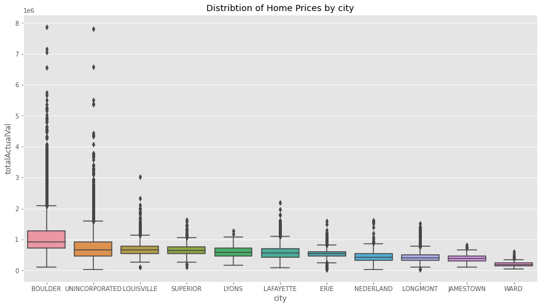

```python
#Boxplot of Actual Value by City
my_order = boulder.groupby(by=["city"])["totalActualVal"].median()

fig, ax1 = plt.subplots(figsize=(15,8))
my_order = boulder.groupby(by=["city"])["totalActualVal"].median().sort_values(ascending = False).index
sns.boxplot(x = 'city', y = 'totalActualVal', data = boulder, order = my_order, ax = ax1)
ax1.set_title('Distribtion of Home Prices by city')
#boulder.boxplot(column = 'totalActualVal',
#                 by = 'city',
#              figsize = (15,10))
```

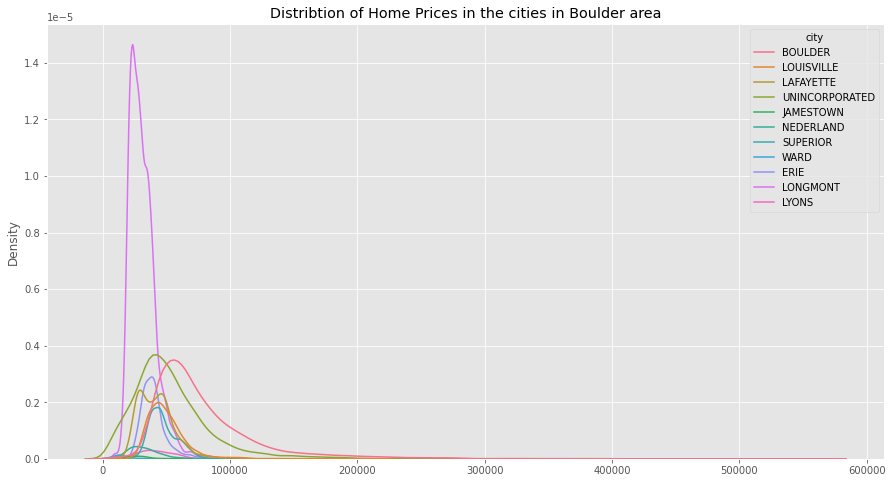

```python
boulder_price2 = boulder[['city', 'totalAssessedVal']]

fig, ax = plt.subplots(figsize=(15,8))
sns.kdeplot(np.array(boulder_price2.totalAssessedVal), ax=ax, hue = boulder_price2.city)
ax.set_title('Distribtion of Home Prices in the cities in Boulder area')
```

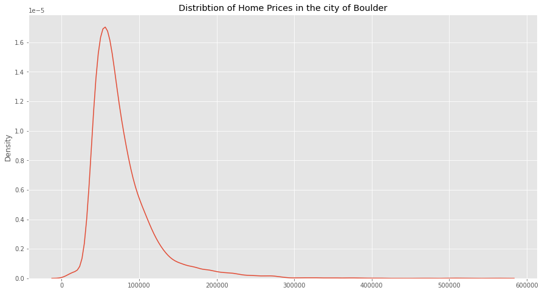

```python
boulder_price = boulder.loc[boulder['city'] == 'BOULDER', ['city', 'totalAssessedVal']]

fig, ax = plt.subplots(figsize=(15,8))
sns.kdeplot(np.array(boulder_price.totalAssessedVal), ax=ax)
ax.set_title('Distribtion of Home Prices in the city of Boulder')
```

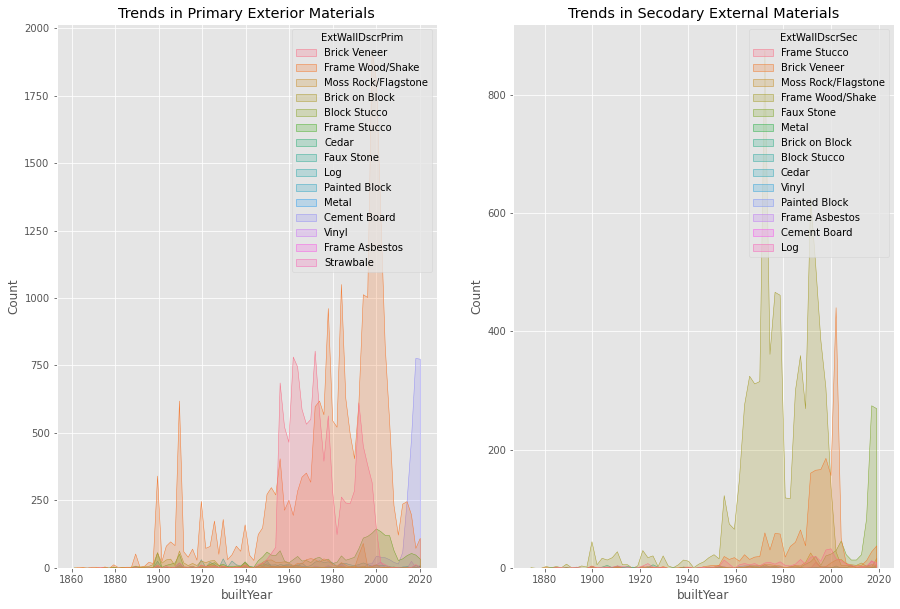

```python
fig, (axes_1, axes_2) = plt.subplots(1,2, figsize=(15,10))
axes_1.set_title('Trends in Primary Exterior Materials')
axes_2.set_title('Trends in Secodary External Materials')
sns.histplot(buildings, x = "builtYear", element = 'poly',  ax = axes_1, hue= 'ExtWallDscrPrim')
sns.histplot(buildings, x = "builtYear", element = 'poly',  ax = axes_2, hue= 'ExtWallDscrSec')
```

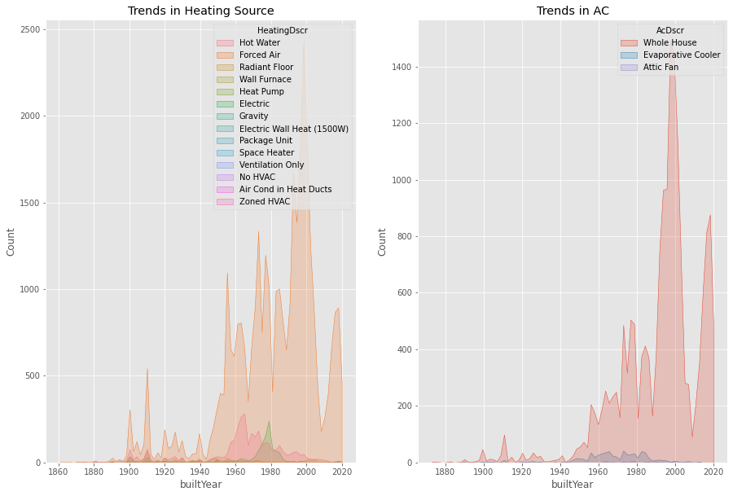

```python
fig, (axes_1, axes_2) = plt.subplots(1,2, figsize=(15,10))
axes_1.set_title('Trends in Heating Source')
axes_2.set_title('Trends in AC')
sns.histplot(buildings, x = "builtYear", element = 'poly',  ax = axes_1, hue= 'HeatingDscr')
sns.histplot(buildings, x = "builtYear", element = 'poly',  ax = axes_2, hue= 'AcDscr')
```

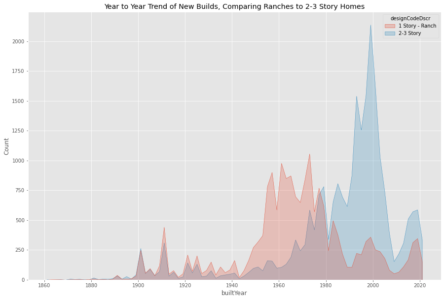

```python
fig, (axes_1) = plt.subplots(1, figsize=(15,10))
axes_1.set_title('Year to Year Trend of New Builds, Comparing Ranches to 2-3 Story Homes')
sns.histplot(buildings, x = "builtYear", element = 'poly', ax = axes_1, hue= 'designCodeDscr')
```

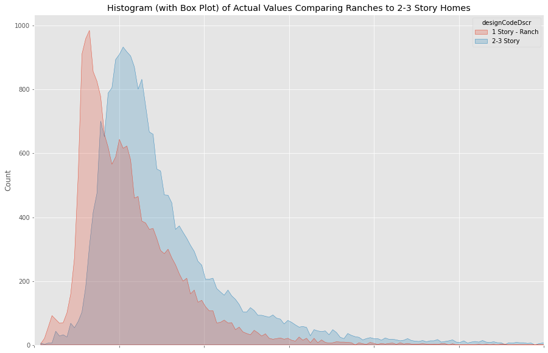

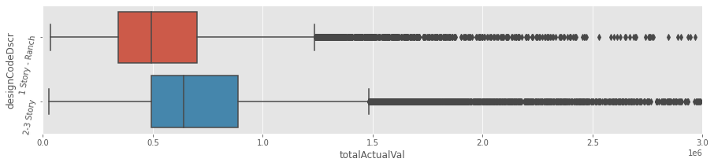

```python
fig, (axes_1) = plt.subplots(1, figsize=(15,10))
axes_1.set_title('Histogram (with Box Plot) of Actual Values Comparing Ranches to 2-3 Story Homes')
axes_1.set_xlim(0,3000000)

sns.histplot(x=boulder.totalActualVal, hue = boulder.designCodeDscr, ax = axes_1, element = 'poly')
axes_1.set(xticklabels=[])
axes_1.set(xlabel= None)


fig, (axes_2) = plt.subplots(1, figsize=(15,3))
sns.boxplot(x =  boulder.totalActualVal, y = boulder.designCodeDscr, ax = axes_2)
axes_2.set_xlim(0,3000000)
axes_2.tick_params(axis='y', rotation=80)
```

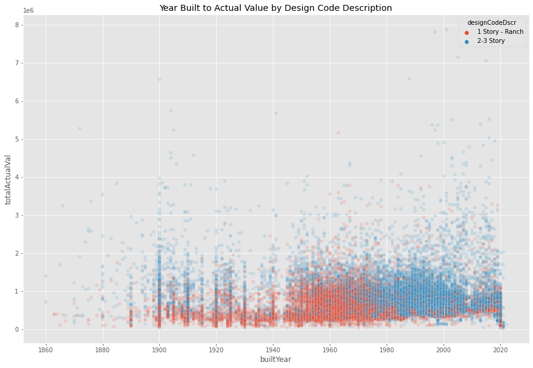

```python
fig, (axes_1) = plt.subplots(1, figsize=(15,10))
axes_1.set_title('Year Built to Actual Value by Design Code Description')
sns.scatterplot(x = boulder.builtYear,
                y = boulder.totalActualVal,
                alpha = .15,
                hue = boulder.designCodeDscr,
                ax = axes_1)
```

## Part II: Algorithmic Thinking

### Objective

In this portion of the assignment, our goal is to predict the value of a new single-family property given comparable sales data. One way we might estimate the value of a home is to look at the value of *k*-similar nearby homes that have recently sold. The average sales price of those *k* homes could then be used as the predicted valuation for our new home. This process is effectively how the K-Nearest Neighbor Algorithm (KNN) works for regression problems.

KNN is considered a supervised machine learning algorithm that can be used to solve both classification and regression problems. As shown above, we can be used to solve nonparametric regression problems such as predicting the price of a new home based on *similar* nearby homes.

Recall the central factors used for property valuation:

- Location
- Living Area (SQFT)
- Age of the Home
- Finished Basement

### 2.0 Read and Prepare the Sales Data (15 pts)

Tasks:

- Load the sales.csv
- Keep only qualified sales (sales.sales_cd == 'Q') and sales.price > 0.
- Keep only sales in the last 5 years (01/01/2015 and 12/31/2020)
- Join "sales" with the necessary data frames to add the following columns
  - nh, this is the neighborhood number that must be used to identify comparable sales by location.
  - totalActualVal
  - builtYear
  - EffectiveYear
  - TotalFinishedSF
  - A boolean flag (1/0) for if the basement is finished that you will need to create

```python
sales = pd.read_csv("sales.csv")
sales.head(5)
sales.info()
```

```
<class 'pandas.core.frame.DataFrame'>
RangeIndex: 221137 entries, 0 to 221136
Data columns (total 7 columns):
 #   Column     Non-Null Count   Dtype
---  ------     --------------   -----
 0   strap      221137 non-null  object
 1   deedNum    221124 non-null  object
 2   Tdate      221137 non-null  object
 3   sales_cd   221137 non-null  object
 4   deed_type  221137 non-null  object
 5   price      217641 non-null  float64
 6   status_cd  221137 non-null  object
dtypes: float64(1), object(6)
memory usage: 11.8+ MB
```

```python
sales.Tdate =  pd.to_datetime(sales.Tdate)
sales.info()
sales.head(5)
```

```
<class 'pandas.core.frame.DataFrame'>
RangeIndex: 221137 entries, 0 to 221136
Data columns (total 7 columns):
 #   Column     Non-Null Count   Dtype
---  ------     --------------   -----
 0   strap      221137 non-null  object
 1   deedNum    221124 non-null  object
 2   Tdate      221137 non-null  datetime64[ns]
 3   sales_cd   221137 non-null  object
 4   deed_type  221137 non-null  object
 5   price      217641 non-null  float64
 6   status_cd  221137 non-null  object
dtypes: datetime64[ns](1), float64(1), object(5)
memory usage: 11.8+ MB
```

|  | strap | deedNum | Tdate | sales_cd | deed_type | price | status_cd |
| --- | --- | --- | --- | --- | --- | --- | --- |
| 0 | R0000005 | 416158 | 1980-10-07 | Q | WJ | 89500.0 | A |
| 1 | R0000005 | 1317705 | 1993-07-26 | Q | WD | 149900.0 | A |
| 2 | R0000005 | 2316275 | 2002-07-18 | Q | WD | 345000.0 | A |
| 3 | R0000005 | 2316274 | 2002-07-30 | Q | WD | 345000.0 | A |
| 4 | R0000006 | 864603 | 1967-11-27 | U | QD | NaN | A |

```python
filt1 = sales.sales_cd == 'Q'
filt2 = sales.price > 0
filt3 = sales.Tdate >= '2015-01-01'
filt4 = sales.Tdate <= '2020-12-31'
filt = filt1 & filt2 & filt3 & filt4
sales = sales[filt]
sales.info()
sales.head(5)
```

```
<class 'pandas.core.frame.DataFrame'>
Int64Index: 11759 entries, 26 to 221106
Data columns (total 7 columns):
 #   Column     Non-Null Count  Dtype
---  ------     --------------  -----
 0   strap      11759 non-null  object
 1   deedNum    11759 non-null  object
 2   Tdate      11759 non-null  datetime64[ns]
 3   sales_cd   11759 non-null  object
 4   deed_type  11759 non-null  object
 5   price      11759 non-null  float64
 6   status_cd  11759 non-null  object
dtypes: datetime64[ns](1), float64(1), object(5)
memory usage: 734.9+ KB
```

|  | strap | deedNum | Tdate | sales_cd | deed_type | price | status_cd |
| --- | --- | --- | --- | --- | --- | --- | --- |
| 26 | R0000013 | 3490566 | 2015-12-14 | Q | WJ | 1315000.0 | A |
| 32 | R0000017 | 3686840 | 2018-11-20 | Q | WD | 728500.0 | A |
| 58 | R0000026 | 3575976 | 2017-02-15 | Q | WD | 1240000.0 | A |
| 62 | R0000028 | 3672204 | 2018-08-15 | Q | WD | 2350000.0 | A |
| 99 | R0000038 | 3458700 | 2015-06-15 | Q | WD | 569900.0 | A |

```python
#Joining all tables into one clean dataframe

knnBuildings = buildings[['strap','builtYear','EffectiveYear','TotalFinishedSF','bsmtType']]
knnLocations = owner_addresses[['strap','nh']]
knnValues = values[['strap','totalActualVal']]

knnSales1 = pd.merge(sales,
                    knnBuildings,
                    how = 'left',
                    on = 'strap')

knnSales2= pd.merge(knnSales1,
                    knnLocations,
                    how = 'left',
                    on = 'strap')

knnSales = pd.merge(knnSales2,
                    knnValues,
                    how = 'left',
                    on = 'strap')

knnSales.head(10)
```

|  | strap | deedNum | Tdate | sales_cd | deed_type | price | status_cd | builtYear | EffectiveYear | TotalFinishedSF | bsmtType | nh | totalActualVal |
| --- | --- | --- | --- | --- | --- | --- | --- | --- | --- | --- | --- | --- | --- |
| 0 | R0000013 | 3490566 | 2015-12-14 | Q | WJ | 1315000.0 | A | 1973 | 1995 | 3111 | BSU | 120.0 | 1838000 |
| 1 | R0000017 | 3686840 | 2018-11-20 | Q | WD | 728500.0 | A | 1968 | 1985 | 1213 | BSF | 120.0 | 876000 |
| 2 | R0000026 | 3575976 | 2017-02-15 | Q | WD | 1240000.0 | A | 1891 | 1983 | 3022 | BSF | 102.0 | 1715000 |
| 3 | R0000028 | 3672204 | 2018-08-15 | Q | WD | 2350000.0 | A | 1945 | 1985 | 1905 | BWF | 103.0 | 2225500 |
| 4 | R0000038 | 3458700 | 2015-06-15 | Q | WD | 569900.0 | A | 1900 | 1960 | 660 | 0 | 109.0 | 668000 |
| 5 | R0000048 | 3668583 | 2018-07-27 | Q | WJ | 980000.0 | A | 1930 | 1990 | 1843 | 0 | 109.0 | 1069500 |
| 6 | R0000050 | 3676451 | 2018-09-12 | Q | WD | 1800000.0 | A | 1900 | 2000 | 2697 | BSF | 170.0 | 1946000 |
| 7 | R0000084 | 3802972 | 2020-06-23 | Q | RD | 675000.0 | A | 1957 | 1995 | 1053 | 0 | 115.0 | 779600 |
| 8 | R0000098 | 3464510 | 2015-07-30 | Q | WJ | 760000.0 | A | 1956 | 1995 | 1395 | 0 | 170.0 | 1132100 |
| 9 | R0000098 | 3633943 | 2017-12-28 | Q | WJ | 880000.0 | A | 1956 | 1995 | 1395 | 0 | 170.0 | 1132100 |

```python
#Adding Boolean Column for Basements Finished/ Unfinished
knnSales['bsmtFinished'] = np.where(knnSales.bsmtType.str.contains('F') == True,1,0)
knnSales = knnSales.drop(columns = 'bsmtType')

knnSales.head(5)
```

|  | strap | deedNum | Tdate | sales_cd | deed_type | price | status_cd | builtYear | EffectiveYear | TotalFinishedSF | nh | totalActualVal | bsmtFinished |
| --- | --- | --- | --- | --- | --- | --- | --- | --- | --- | --- | --- | --- | --- |
| 0 | R0000013 | 3490566 | 2015-12-14 | Q | WJ | 1315000.0 | A | 1973 | 1995 | 3111 | 120.0 | 1838000 | 0 |
| 1 | R0000017 | 3686840 | 2018-11-20 | Q | WD | 728500.0 | A | 1968 | 1985 | 1213 | 120.0 | 876000 | 1 |
| 2 | R0000026 | 3575976 | 2017-02-15 | Q | WD | 1240000.0 | A | 1891 | 1983 | 3022 | 102.0 | 1715000 | 1 |
| 3 | R0000028 | 3672204 | 2018-08-15 | Q | WD | 2350000.0 | A | 1945 | 1985 | 1905 | 103.0 | 2225500 | 1 |
| 4 | R0000038 | 3458700 | 2015-06-15 | Q | WD | 569900.0 | A | 1900 | 1960 | 660 | 109.0 | 668000 | 0 |

### 2.1 Property Valuation using KNN (20 pts)

Tasks:

- Complete the below function **predict_knn()** so that it finds the k-most similar sales properties in the appraisal neighborhood (nh) and returns the average sale price for those *k* properties as the predicted value (y_hat).

How this problem will be graded:

- You will not be graded on your prediction accuracy or the value of *k* you select. You will be graded on how you write your code and, in particular, if you took advantage of vectorization. You must write your own knn function from scratch, do not use sklearn.neighbors.KNeighborsRegressor.

#### KNN Regression Pseudo Code

Given a new data point:

1. Calculate the Euclidean distance between the new data point and all known datapoints in the dataset.
2. Select the *k* closest datapoints.
3. Average the target variable for the *k* closest data points.

Euclidean Distance formula for 3-dimenstions where p_1 and q_1 is finished_sqft, p2 and q_2 is home_age, and p3 and q_3 is finished_basement:

$$d(p,q)=\sqrt{(p_1-q_1)^2 + (p_2-q_2)^2 + (p_3-q_3)^2}$$

.

```python
def predict_knn(sales_data, k, nh, finished_sqft, home_age, finished_basement):

    #error for invalid neighborhood
    if nh not in sales_data.nh.unique():
        raise TypeError("Invalid Neighborhood")

    #error for invalue k value
    if k < 3:
        raise TypeError("K must be larger than 3")

    #if not isinstance(home_age, (int, float)):
    #    raise TypeError("home_age must be numeric")

    #if not isinstance(finished_sqft, (int, float)):
    #    raise TypeError("finished_sqft must be numeric")

    #if not isinstance(finished_basement, (int,bool)):
    #    raise TypeError("finished_basement must be T/F or 1/0")

    #if finished_basement > 1:
    #    raise TypeError("finished_basement must be T/F or 1/0")

    #if finished_basement < 0:
    #    raise TypeError("finished_basement must be T/F or 1/0")

    # Filter down to our sales data to the provided neighborhood number, nh.
    sales_data = sales_data[sales_data.nh == nh]

    #Adding 2 to k, will remove two of the outlier properties below
    k = k+2

    # Calculate the Euclidean Distance for finished_sqft, home_age, and finished_basement for every sale in our nh.
    knnFilt = np.sqrt(
        (finished_sqft - sales_data.TotalFinishedSF)**2+
        #Weighted basement more heavily otherwise the 1/0 will have no real effect compared to finished sqft or home age
        (finished_basement*10 - sales_data.bsmtFinished*10)**2+
        #Avg-ing Home Age Difference by Built year and Effective Year
        (home_age - (2021 - (sales_data.EffectiveYear+sales_data.builtYear)/2))**2
    ).sort_values().head(k).index

    compared_props = sales_data.loc[knnFilt]

    #Removing most and least expensive properties from list to leave k values
    y_hat = compared_props[:-1].tail(-1).totalActualVal.mean().round(2)

    return y_hat
```

```python
# Validate your function works for a new home in nh 200 that is 1500 sqft, 5 years old, and does not have a finished basement.

# See next chunk for nb 200 since it produces an error.

print(predict_knn(sales_data = knnSales, k=4, nh=201, finished_sqft=3500, home_age=9, finished_basement=0))
print(predict_knn(sales_data = knnSales, k=5, nh=930, finished_sqft=2500, home_age=6, finished_basement=0))
print(predict_knn(sales_data = knnSales, k=6, nh=155, finished_sqft=500, home_age=34, finished_basement=0))
print(predict_knn(sales_data = knnSales, k=7, nh=472, finished_sqft=8500, home_age=1.5, finished_basement=0))
```

```
734550.0
463853.0
519616.67
1042642.86
```

```python
#Testing Errors
predict_knn(sales_data = knnSales, k=3, nh=200, finished_sqft=1500, home_age=96, finished_basement=0)
```

```
---------------------------------------------------------------------------
TypeError                                 Traceback (most recent call last)
~\AppData\Local\Temp\1/ipykernel_9548/2964382250.py in <module>
      1 #Testing Errors
----> 2 predict_knn(sales_data = knnSales, k=3, nh=200, finished_sqft=1500, home_age=96, finished_basement=0)

~\AppData\Local\Temp\1/ipykernel_9548/3318731301.py in predict_knn(sales_data, k, nh, finished_sqft, home_age, finished_basement)
      3     #error for invalid neighborhood
      4     if nh not in sales_data.nh.unique():
----> 5         raise TypeError("Invalid Neighborhood")
      6
      7     #error for invalue k value

TypeError: Invalid Neighborhood
```

### 2.2 Test your KNN function (10 pts).

Select 10 or more existing home valuations at random and compare the results of predict_knn() to the Accessors's provided valuation (In values.csv, the totalActualVal column). How do your predictions perform relative to the Accessor's valuation as you try different values of *k*?

```python
knnSales_copy = knnSales.copy()
```

```python
#Creating new fields to test each house on differenct k-values to store the Predicted Value in
knnSales_copy['Pred_k_5'] = 0
knnSales_copy['Pred_k_10'] = 0
knnSales_copy['Pred_k_15'] = 0
knnSales_copy['Pred_k_20'] = 0
```

```python
#Predicting values for k = 5,10,15,20 to determine if there is a best option.

for i in range(len(knnSales_copy)):
    knnSales_copy['Pred_k_5'][i] = predict_knn(knnSales,
                                                5,
                                                knnSales.nh[i],
                                                knnSales.TotalFinishedSF[i],
                                                2021 - knnSales.EffectiveYear[i],
                                                knnSales.bsmtFinished[i])
for i in range(len(knnSales_copy)):
    knnSales_copy['Pred_k_10'][i] = predict_knn(knnSales,
                                                10,
                                                knnSales.nh[i],
                                                knnSales.TotalFinishedSF[i],
                                                2021 - knnSales.EffectiveYear[i],
                                                knnSales.bsmtFinished[i])
for i in range(len(knnSales_copy)):
    knnSales_copy['Pred_k_15'][i] = predict_knn(knnSales,
                                                15,
                                                knnSales.nh[i],
                                                knnSales.TotalFinishedSF[i],
                                                2021 - knnSales.EffectiveYear[i],
                                                knnSales.bsmtFinished[i])
for i in range(len(knnSales_copy)):
    knnSales_copy['Pred_k_20'][i] = predict_knn(knnSales,
                                                20,
                                                knnSales.nh[i],
                                                knnSales.TotalFinishedSF[i],
                                                2021 - knnSales.EffectiveYear[i],
                                                knnSales.bsmtFinished[i])
```

```python
knnSales_copy.head(10)
```

|  | strap | deedNum | Tdate | sales_cd | deed_type | price | status_cd | builtYear | EffectiveYear | TotalFinishedSF | nh | totalActualVal | bsmtFinished | Pred_k_5 | Pred_k_10 | Pred_k_15 | Pred_k_20 |
| --- | --- | --- | --- | --- | --- | --- | --- | --- | --- | --- | --- | --- | --- | --- | --- | --- | --- |
| 0 | R0000013 | 3490566 | 2015-12-14 | Q | WJ | 1315000.0 | A | 1973 | 1995 | 3111 | 120.0 | 1838000 | 0 | 2272120 | 1971110 | 1867960 | 1804470 |
| 1 | R0000017 | 3686840 | 2018-11-20 | Q | WD | 728500.0 | A | 1968 | 1985 | 1213 | 120.0 | 876000 | 1 | 907120 | 845880 | 891366 | 927885 |
| 2 | R0000026 | 3575976 | 2017-02-15 | Q | WD | 1240000.0 | A | 1891 | 1983 | 3022 | 102.0 | 1715000 | 1 | 2421468 | 2241723 | 2172975 | 2012636 |
| 3 | R0000028 | 3672204 | 2018-08-15 | Q | WD | 2350000.0 | A | 1945 | 1985 | 1905 | 103.0 | 2225500 | 1 | 1641860 | 1602060 | 1768429 | 1768162 |
| 4 | R0000038 | 3458700 | 2015-06-15 | Q | WD | 569900.0 | A | 1900 | 1960 | 660 | 109.0 | 668000 | 0 | 928460 | 930300 | 912033 | 953315 |
| 5 | R0000048 | 3668583 | 2018-07-27 | Q | WJ | 980000.0 | A | 1930 | 1990 | 1843 | 109.0 | 1069500 | 0 | 1507920 | 1391680 | 1382906 | 1382795 |
| 6 | R0000050 | 3676451 | 2018-09-12 | Q | WD | 1800000.0 | A | 1900 | 2000 | 2697 | 170.0 | 1946000 | 1 | 1931680 | 2020540 | 1923180 | 1884850 |
| 7 | R0000084 | 3802972 | 2020-06-23 | Q | RD | 675000.0 | A | 1957 | 1995 | 1053 | 115.0 | 779600 | 0 | 824340 | 818220 | 800193 | 797690 |
| 8 | R0000098 | 3464510 | 2015-07-30 | Q | WJ | 760000.0 | A | 1956 | 1995 | 1395 | 170.0 | 1132100 | 0 | 1205240 | 1236860 | 1178513 | 1153155 |
| 9 | R0000098 | 3633943 | 2017-12-28 | Q | WJ | 880000.0 | A | 1956 | 1995 | 1395 | 170.0 | 1132100 | 0 | 1205240 | 1236860 | 1178513 | 1153155 |

```python
#Trying Some Linear Regression Funky Business but lets be honest, I'm not entirely sure what I am doing.

x0 = knnSales_copy.totalActualVal.values.reshape(-1,1)
y5 = knnSales_copy.Pred_k_5.values.reshape(-1,1)
y10 = knnSales_copy.Pred_k_10.values.reshape(-1,1)
y15 = knnSales_copy.Pred_k_15.values.reshape(-1,1)
y20 = knnSales_copy.Pred_k_20.values.reshape(-1,1)
lr = LinearRegression()
model5 = lr.fit(x0,y5)
model10 = lr.fit(x0,y10)
model15 = lr.fit(x0,y15)
model20 = lr.fit(x0,y20)

y_Pred = lr.predict(x0)
```

```python
print(model5.score(x0,y5))
print(model10.score(x0,y10))
print(model15.score(x0,y15))
print(model20.score(x0,y20))
```

```
0.8158924364723894
0.814916590316297
0.8134767370731745
0.8034588228743765
```

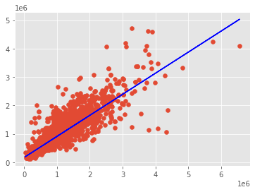

```python
plt.scatter(x0,y5)
plt.plot(x0,y_Pred, color = 'blue')
plt.show()
```

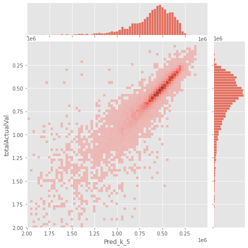

```python
sns.jointplot(x="Pred_k_5",
              y="totalActualVal",
              data=knnSales_copy,
              kind="hist",
              xlim = 2000000,
              ylim = 2000000,
              height=7)
```

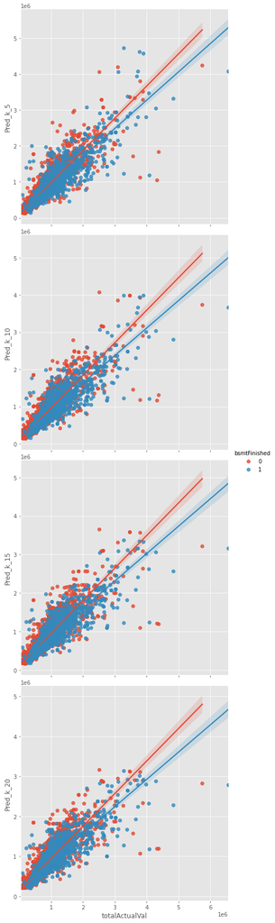

```python
sns.pairplot(data = knnSales_copy,
             x_vars = 'totalActualVal',
             y_vars = ['Pred_k_5', 'Pred_k_10', 'Pred_k_15','Pred_k_20'],
            height = 6,
            kind = 'reg',
            hue = 'bsmtFinished')

#Appears that the unfinished basement properties are being perdicted more accuratly (Regression line closer to x = y)
#Would need to continue looking into many variable like this to make the prediction better,
```

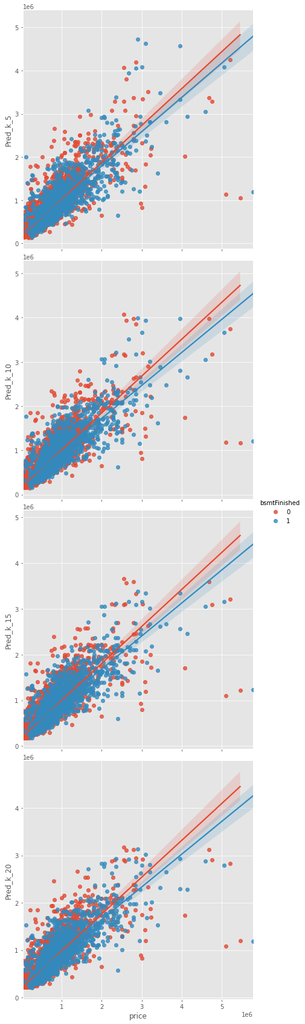

```python
#Looking at Price instead of Actual Value
sns.pairplot(data = knnSales_copy,
             x_vars = 'price',
             y_vars = ['Pred_k_5', 'Pred_k_10', 'Pred_k_15','Pred_k_20'],
            height = 6,
            kind = 'reg',
            hue = 'bsmtFinished')
```

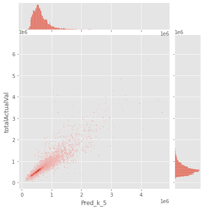

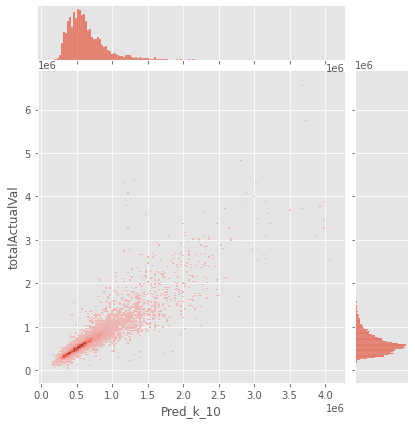

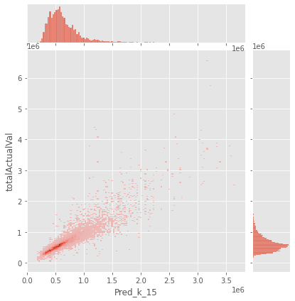

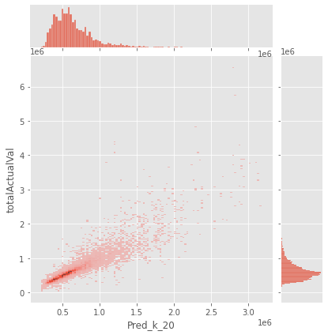

```python
# Answer

sns.jointplot(x="Pred_k_5",
              y="totalActualVal",
              data=knnSales_copy,
              kind="hist")

sns.jointplot(x="Pred_k_10",
              y="totalActualVal",
              data=knnSales_copy,
              kind="hist")

sns.jointplot(x="Pred_k_15",
              y="totalActualVal",
              data=knnSales_copy,
              kind="hist")

sns.jointplot(x="Pred_k_20",
              y="totalActualVal",
              data=knnSales_copy,
              kind="hist")
```

#### Answer

One of the major considerations in this data set is differentiating between Price and TotalActualValue. Price being the most accurate representaion of what the market will bring for a given property vs the more subjective valuation of the assessor.

Depending on how the prediction was actually being used there could be made a strong case for one to appeal a prediction. The results are far from perfect and would be best served as an initial guideline and not a concrete solution. In the beginning, while the algorithm as being fine tuned, that appeal amount may have a wider margin. The goal would be to reduce that margin of error over time so the differnce of amount in which they could appeal would decrease.

## Part III: Ethics Review

Whenever we are modeling our data, it's critical that we take time to consider the impact our algorithms have on people's lives.

### 3.0 (5 pts)

Write a short paragraph that addresses the following questions. No code is required.

1. Describe one possible source of bias that exist might exist in this dataset and impact our estimated valuation?
2. What potential harm could arise due to how our knn regression algorithm works? For example, what if *k* is too low or too high? What impact can outliers have? Would it make sense to normalize (e.g. standardize our values between 0 and 1) for our data points (sqft, age, basement) before calculating Euclidean Distance?
3. Should we have an appeal process for people that may be harmed by the results of our model?